# MC5 Hobo Pressure Workflow

The markdown file documents the data processing of Hobo pressure records collected at the MC5 / McDowell Trib monitoring location.

# Standard Initialization and Needed Libraries

```r
## Clear stuff
rm(list=ls())
graphics.off()

library("zoo")
library("broom")
```

# Define a Function to Read In Raw .csv Files

The atmospheric and water pressure files are not necessarily synchronized in time. Use a spline fit to predict data on the 0:00, 0:05, 0:10 stamps, from the raw data which may be 0:02, 0:07, 0:12, ….

```r
## Define a function to run through a list of dfs, name cols, covert dates
readHoboInterp <- function(dataFile) {
    ## Read in file, rename resulting df columns
    data <- read.csv(paste0("c:/Users/95218/Documents/R/MC5/", dataFile),
                     sep=",", stringsAsFactors=FALSE, skip=1, header=TRUE)
    data <- data[ ,c(2,3,4)]
    names(data) <- c("dt", "hoboPSI", "hoboF")

    ## Format dates from excel files
    data$dt <- strptime(data$dt, format="%m/%d/%y %I:%M:%S %p",
                        tz="America/Panama")
    data$dt <- as.POSIXct(data$dt)

    ## Create regulalry spaced 5 minute time series overlapping data file
    regTS <- data.frame(dt=seq.POSIXt(to=tail(data$dt,6)[6], by=300,
                      from=round(data$dt[1],"mins")-
                          (round(data$dt[1],"mins")$min%%5)*60),kp=1)

    ## Merge even spaced dt with raw data frame
    dataMerged <- merge(data, regTS, by="dt", all=TRUE)

    ## Interpolate the psi series to the even 5 min time stamps
    zooObj <- zoo(dataMerged[2], dataMerged$dt)
    spline1 <- na.spline(zooObj, na.rm=FALSE)
    dataMerged$MC5ModlPsi <- coredata(spline1)

    ## Interpolate the temperature series to the even 5 min time stamps
    zooObj2 <- zoo(dataMerged[3], dataMerged$dt)
    spline2 <- na.spline(zooObj2, na.rm=FALSE)
    dataMerged$MC5ModlTempF <- coredata(spline2)

    ## drop all but dt, interp temp, interp psi
    dataMerged <- dataMerged[which(dataMerged$kp==1),c(1,5,6)]

    return(dataMerged)
}
```

# Create file lists of all air and water files in the current file directory

Code will do a recursive pattern match to find all files. Note that any .cvs contiaing “air” or “water” in file names will be pulled in.

```r
## Read the directories of files that CB sent
dataAir <- as.list(list.files(
    path="c:/Users/95218/Documents/R/MC5",
    pattern="Air.*\\.csv", recursive=TRUE))

dataWater <- as.list(list.files(
    path="c:/Users/95218/Documents/R/MC5",
    pattern="Water.*\\.csv", recursive=TRUE))
```

# Pass those file lists into the function readHoboInterp (defined above)

This will take the lists of file names generated in previous step and send them through lapply() into the user defined function. Then rbind() the resulting lists into data frames, and sort. The next few steps drop some structural artifacts, convert units, cleanup. The ‘Gap Fill’ steps on airFrame insert a regulalry spaced 5 minute timestamp for later gap backfilling via CLT Airport data.

```r
## Pass df of water press. file names to f(), rbind results, sort
waterList <- lapply(dataWater, readHoboInterp)
waterFrame <- do.call("rbind", waterList)
waterFrame <- waterFrame[order(waterFrame$dt), ]

## Drop the [:,1] structure
dimnames(waterFrame$MC5ModlPsi) <- NULL
dimnames(waterFrame$MC5ModlTempF) <- NULL
waterFrame$MC5ModlPsi <- waterFrame$MC5ModlPsi[,1]
waterFrame$MC5ModlTempF <- waterFrame$MC5ModlTempF[,1]

## Some unit conversions
waterFrame$MC5ModlHPa <- waterFrame$MC5ModlPsi*68.94757
waterFrame$MC5ModlTempC <- (waterFrame[,"MC5ModlTempF"]-32)/1.8

## Pass df of air press. file names to f(), rbind results, sort
airList <- lapply(dataAir, readHoboInterp)
airFrame <- do.call("rbind", airList)
airFrame <- airFrame[order(airFrame$dt), ]

## Fill gaps with NAs, tempertature regression and pressure convr. from CLT
gapFill <- data.frame(dt=seq.POSIXt(to=tail(airFrame$dt,6)[6], by=300,
                      from=waterFrame$dt[1]))
airFrame <- merge(airFrame, gapFill, by="dt", all=TRUE)

## Drop the [:,1] structure
dimnames(airFrame$MC5ModlPsi) <- NULL
dimnames(airFrame$MC5ModlTempF) <- NULL
airFrame$MC5ModlPsi <- airFrame$MC5ModlPsi[,1]
airFrame$MC5ModlTempF <- airFrame$MC5ModlTempF[,1]

## Some unit conversions
airFrame$MC5ModlHPa <- airFrame$MC5ModlPsi*68.94757
airFrame$MC5ModlTempC <- (airFrame[,"MC5ModlTempF"]-32)/1.8

rm(dataAir, dataWater, readHoboInterp, gapFill, waterList, airList)
```

# Plot the 5 minute data (interpolated to even stamps)

This plot shows that we have temporal gaps in both records. Water is not correctable, but air can potentially be backfilled by atmospheric pressure data from elsewhere (e.g, CLT).

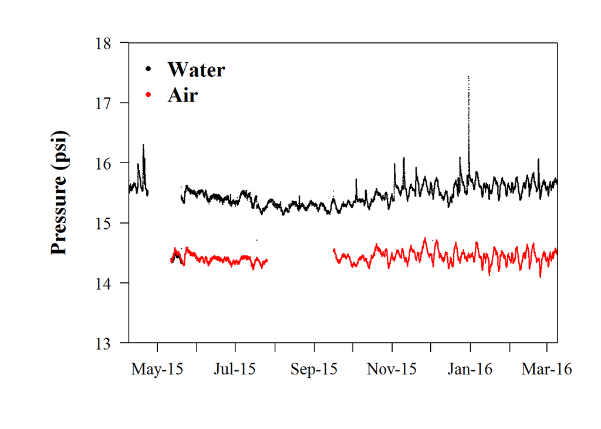

```r
## Plot spline fits of raw pressure files
dateTicks <- seq.POSIXt(from=as.POSIXct("2015-04-01"),
                      to=max(waterFrame$dt,airFrame$dt,na.rm=TRUE),
                      by="month")

par(xaxs="i", yaxs="i", mai=c(1,1.5,.5,.5), font=2,
    cex.axis=1.2, family="serif", omi=rep(0,4))
plot(waterFrame$dt, waterFrame$MC5ModlPsi, pch=16,
     axes=FALSE, xlab="", ylab="", ylim=c(13,18), cex=.2)
points(airFrame$dt, airFrame$MC5ModlPsi, pch=16, col="red", cex=.2)
box()
axis.POSIXct(side=1, at=dateTicks, x=dateTicks, format="%b-%y")
axis(2, las=2)
mtext(side=2, "Pressure (psi)", line=3.5, cex=1.5, font=2)
legend("topleft", legend=c("Water", "Air"), pch=16, pt.cex=.75,
       col=c("black", "red"), bty="n", cex=1.5)
```

# Load CLT Airport Data File

From [NOAA, Mecklenburg/CLT](https://www.ncdc.noaa.gov/cdo-web/datatools/lcd), get CLT Airport climate data, save at a .csv.

```r
## Load in the Airport data, format and clean up NAs
cDoug <- read.csv("CLTMet2.csv", header=TRUE, sep=",",
                  stringsAsFactors=FALSE)
cDoug <- cDoug[ ,c("DATE","HOURLYSeaLevelPressure",
                   "HOURLYStationPressure", "HOURLYDRYBULBTEMPC")]
cDoug$dt <- as.POSIXct(cDoug$DATE, format="%m/%d/%Y %H:%M",
                       tz="America/Panama")
## Rename, Slp=sea level press., Stp=station pressure.
names(cDoug) <- c("date", "CLTSlpHgIn", "CLTStpHgIn", "CLTTempC", "dt")

cDoug$CLTSlpHgIn <- as.numeric(cDoug$CLTSlpHgIn)
cDoug$CLTStpHgIn <- as.numeric(cDoug$CLTStpHgIn)
cDoug$CLTSlpHPa <- cDoug$CLTSlpHgIn*33.8639

cDoug$CLTTempC <- as.numeric(cDoug$CLTTempC)
```

# Plot the CLT pressure series

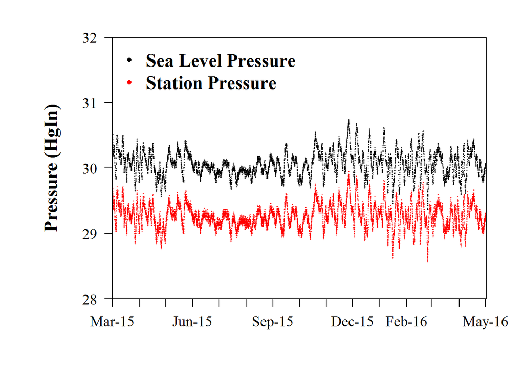

```r
## Plot CLT data
dateTicks <- seq.POSIXt(from=min(cDoug$dt, na.rm=TRUE),
                      to=max(cDoug$dt, na.rm=TRUE),
                      by="month")

par(xaxs="i", yaxs="i", mai=c(1,1.5,.5,.5), font=2,
    cex.axis=1.2, family="serif", omi=rep(0,4))
plot(cDoug$dt, cDoug$CLTSlpHgIn, pch=16,
     axes=FALSE, xlab="", ylab="", ylim=c(28,32), cex=.2)
points(cDoug$dt, cDoug$CLTStpHgIn, pch=16, col="red", cex=.2)
box()
axis.POSIXct(side=1, at=dateTicks, x=dateTicks, format="%b-%y")
axis(2, las=2)
mtext(side=2, "Pressure (HgIn)", line=3.5, cex=1.5, font=2)
legend("topleft", legend=c("Sea Level Pressure", "Station Pressure"),
       pch=16, pt.cex=.75, col=c("black", "red"), bty="n", cex=1.5)
```

# Next, see how well CLT pressure data corresponds with MC5 barometric pressure

We’ll need to back fill the MC5 barometric pressure series to cover the gap from mid-July 2015 to Sept. 2015. This can be done by taking CLT Sea Level Pressure and converting it MC5 pressure using the MC5 elevation and air temperatures. Below is a (slow) loop to do just that.

```r
## Loop over cDoug records and convert cDoug SLP to station pressure
## at MC5 using MC5 temperature...
for (j in 1:nrow(cDoug)) {
    currentMatch <- j
    currentIndex <- which.min(abs(airFrame$dt-cDoug$dt[j]))

    tempA <- airFrame$MC5ModlTempC[currentIndex]
    minus12 <- which.min(abs(airFrame$dt-(cDoug$dt[j]-(60*60*12))))
    tempB <- airFrame$MC5ModlTempC[minus12]
    T <- (sum(tempA,tempB,na.rm=TRUE)/2) +273
    cDoug$MC5StpHpa[j] <-
        cDoug$CLTSlpHPa[j]*exp(-((668)/3.2808)/(T*29.263))
    rm(tempA,tempB,T)
}
```

Next, we’ll put together all data where at given time stamp we have 1) a barometric pressure reading at MC5, and 2) an estimate of barometric pressure at MC5 calculated using MC5 temperature records, and then make a plot to visualize correspondence.

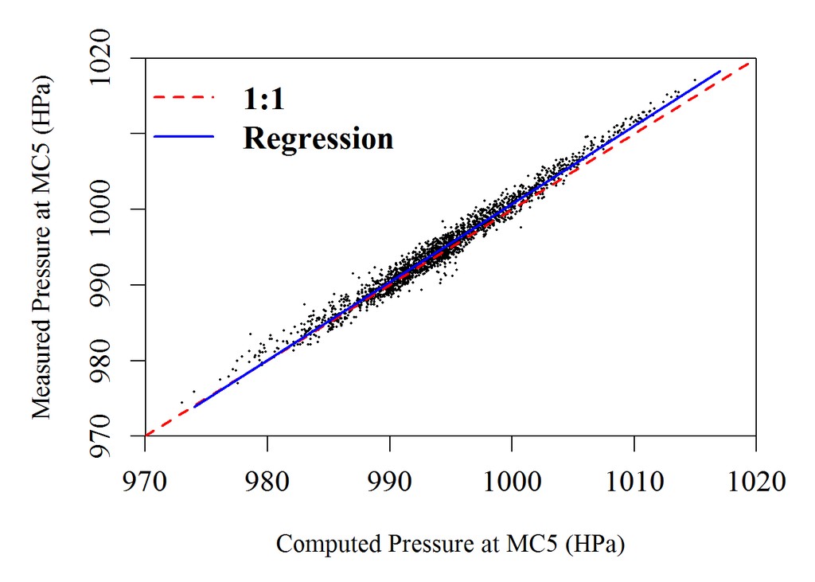

```r
## Merge the MC5 File with the cDoug file to see how well actual MC5 HPa
## corresponds with CLT estimated MC5 HPa
tempData <- merge(cDoug, airFrame, by="dt", all=FALSE)

par(xaxs="i", yaxs="i", mai=c(1.25,1.25,.5,.5), font=2,
    cex.axis=1.2, family="serif", omi=rep(0,4), cex=1.3)
plot(x=tempData$MC5StpHpa, y=tempData$MC5ModlHPa, pch=16,
     cex=.2, xlim=c(970,1020), ylim=c(970,1020),
     xlab="Computed Pressure at MC5 (HPa)",
     ylab="Measured Pressure at MC5 (HPa)")
box()
lines(x=c(970,1020), y=c(970,1020), col="red", lwd=2, lty=2)

dataModel <- lm(tempData$MC5ModlHPa~tempData$MC5StpHpa)
tidy1 <- tidy(dataModel)
lines(x=c(974,1017),y=c(tidy1$estimate[2]*974+tidy1$estimate[1],
                     tidy1$estimate[2]*1017+tidy1$estimate[1]),
      col="blue",lwd=2)
legend("topleft", legend=c("1:1", "Regression"),
       pch=NA, lty=c(2,1), lwd=2, col=c("red", "blue"),
       bty="n", cex=1.3)
```

```r
glance(dataModel)
```

```
##   r.squared adj.r.squared    sigma statistic p.value df    logLik      AIC
## 1 0.9738016     0.9737884 1.037787  73559.96       0  2 -2883.392 5772.785
##        BIC deviance df.residual
## 1 5789.559 2131.385        1979
```

```r
tidy1
```

```
##                 term   estimate   std.error  statistic      p.value
## 1        (Intercept) -32.284281 3.787622932  -8.523626 3.018377e-17
## 2 tempData$MC5StpHpa   1.033038 0.003808863 271.219401 0.000000e+00
```

# Predict MC5 Barometric Pressure Using Airport Temperatures

Where we have gaps in MC5 Barometric, we also have gaps in MC5 Air Tempertature. So it is of interest how well we can predict MC5 Pressure using Temperature measured at the Airport, as opposed to at the MC5 site.

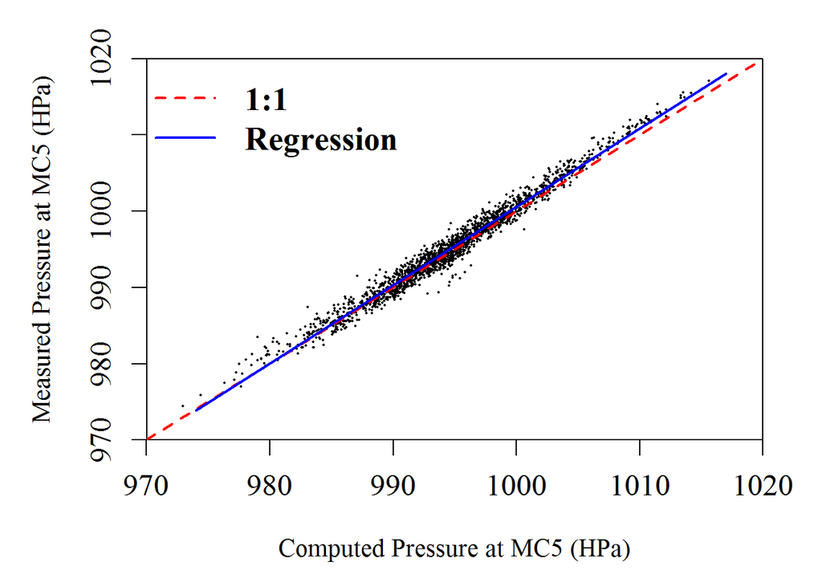

```r
## Similar loop as in above, but grabbing average temperature from
## CLT rather than from MC5
for (j in 1:nrow(cDoug)) {
    currentMatch <- j
    currentIndex <- which.min(abs(cDoug$dt-cDoug$dt[j]))

    tempA <- cDoug$CLTTempC[currentIndex]
    minus12 <- which.min(abs(cDoug$dt-(cDoug$dt[j]-(60*60*12))))
    tempB <- cDoug$CLTTempC[minus12]
    T <- (sum(tempA,tempB,na.rm=TRUE)/2) +273
    cDoug$MC5StpHpaViaClt[j] <-
        cDoug$CLTSlpHPa[j]*exp(-((668)/3.2808)/(T*29.263))
    rm(tempA,tempB,T)
}


## Merge the MC5 File with the cDoug file to see how well actual MC5 HPa
## corresponds with CLT estimated MC5 HPa that is now estimated via
## Airport tempraturte records
tempData2 <- merge(cDoug, airFrame, by="dt", all=FALSE)

par(xaxs="i", yaxs="i", mai=c(1.25,1.25,.5,.5), font=2,
    cex.axis=1.2, family="serif", omi=rep(0,4), cex=1.3)
plot(x=tempData2$MC5StpHpaViaClt, y=tempData2$MC5ModlHPa, pch=16,
     cex=.2, xlim=c(970,1020), ylim=c(970,1020),
     xlab="Computed Pressure at MC5 (HPa)",
     ylab="Measured Pressure at MC5 (HPa)")
box()
lines(x=c(970,1020), y=c(970,1020), col="red", lwd=2, lty=2)

dataModel2 <- lm(tempData2$MC5ModlHPa~tempData2$MC5StpHpaViaClt)
tidy2 <- tidy(dataModel2)
lines(x=c(974,1017),y=c(tidy2$estimate[2]*974+tidy2$estimate[1],
                     tidy2$estimate[2]*1017+tidy2$estimate[1]),
      col="blue",lwd=2)

legend("topleft", legend=c("1:1", "Regression"),
       pch=NA, lty=c(2,1), lwd=2, col=c("red", "blue"),
       bty="n", cex=1.3)
```

```r
glance(dataModel2)
```

```
##   r.squared adj.r.squared    sigma statistic p.value df    logLik      AIC
## 1 0.9748934     0.9748807 1.015932  76844.87       0  2 -2841.229 5688.459
##        BIC deviance df.residual
## 1 5705.233 2042.562        1979
```

```r
tidy2
```

```
##                        term   estimate   std.error  statistic    p.value
## 1               (Intercept) -26.137483 3.683610214  -7.095616 1.7865e-12
## 2 tempData2$MC5StpHpaViaClt   1.026698 0.003703697 277.209071 0.0000e+00
```